# International Housing Market

## [Link to the Dataset](https://www.kaggle.com/datasets/atharvasoundankar/global-housing-market-analysis-2015-2024)

This dataset focuses on the housing market for different countries in different years. It includes things such as mortgage rate, rent index, affordability, and much more. The dataset gives insight into what factors someone purchasing a house in different countries would face.

```python
#Importing Libraries
import pandas as pd
import numpy as np
import matplotlib.pyplot as plt
import seaborn as sns
import plotly.express as px

# Loading Data
df = pd.read_csv("global_housing_market_extended.csv")
```

### Data Understanding

```python
#Getting a general view of the data
print(df)
```

```
    Country  Year  House Price Index  Rent Index  Affordability Ratio  \
0       USA  2015         117.454012  116.550001             9.587945
1       USA  2016         150.807258   51.440915            11.729189
2       USA  2017         123.194502   70.386040             8.506676
3       USA  2018         131.423444   91.469020             3.418054
4       USA  2019         110.461377   56.837048             9.158097
..      ...   ...                ...         ...                  ...
195     UAE  2020         160.153711  117.170365             7.390686
196     UAE  2021          95.004866   72.727315             9.636214
197     UAE  2022         175.533469  105.083237             5.838662
198     UAE  2023         126.147746   94.604103             8.934185
199     UAE  2024         153.743377   85.855534             9.122050

     Mortgage Rate (%)  Inflation Rate (%)  GDP Growth (%)  \
0             4.493292            1.514121       -0.752044
```

[output cut: 25 more lines]

```python
#Printing the first few rows
df.head()
```

|  | Country | Year | House Price Index | Rent Index | Affordability Ratio | Mortgage Rate (%) | Inflation Rate (%) | GDP Growth (%) | Population Growth (%) | Urbanization Rate (%) | Construction Index |
| --- | --- | --- | --- | --- | --- | --- | --- | --- | --- | --- | --- |
| 0 | USA | 2015 | 117.454012 | 116.550001 | 9.587945 | 4.493292 | 1.514121 | -0.752044 | -0.796707 | 85.985284 | 118.089201 |
| 1 | USA | 2016 | 150.807258 | 51.440915 | 11.729189 | 5.662213 | 1.880204 | -0.545400 | -0.358084 | 69.127267 | 111.980515 |
| 2 | USA | 2017 | 123.194502 | 70.386040 | 8.506676 | 2.197469 | 2.398940 | 0.930895 | 0.596245 | 83.555279 | 85.973903 |
| 3 | USA | 2018 | 131.423444 | 91.469020 | 3.418054 | 4.537724 | 1.608407 | -1.479587 | 2.321099 | 88.968961 | 134.671788 |
| 4 | USA | 2019 | 110.461377 | 56.837048 | 9.158097 | 3.700762 | 1.293249 | 1.961415 | -0.879640 | 87.279612 | 90.702399 |

```python
#Printing the last few rows
df.tail()
```

|  | Country | Year | House Price Index | Rent Index | Affordability Ratio | Mortgage Rate (%) | Inflation Rate (%) | GDP Growth (%) | Population Growth (%) | Urbanization Rate (%) | Construction Index |
| --- | --- | --- | --- | --- | --- | --- | --- | --- | --- | --- | --- |
| 195 | UAE | 2020 | 160.153711 | 117.170365 | 7.390686 | 2.048681 | 4.061737 | 1.635019 | 1.955250 | 62.942477 | 109.059291 |
| 196 | UAE | 2021 | 95.004866 | 72.727315 | 9.636214 | 3.880091 | 2.943274 | 1.155810 | 0.608064 | 83.550496 | 141.366775 |
| 197 | UAE | 2022 | 175.533469 | 105.083237 | 5.838662 | 4.940674 | 3.344420 | 0.037365 | 1.943051 | 61.152790 | 142.140959 |
| 198 | UAE | 2023 | 126.147746 | 94.604103 | 8.934185 | 5.975589 | 4.638353 | 2.911469 | -0.766718 | 75.552241 | 82.013520 |
| 199 | UAE | 2024 | 153.743377 | 85.855534 | 9.122050 | 1.708365 | 1.051148 | 3.730587 | -0.747705 | 62.137702 | 70.968678 |

```python
#A closer look at the Data Type for each coloumn
df.info()
```

```
<class 'pandas.core.frame.DataFrame'>
RangeIndex: 200 entries, 0 to 199
Data columns (total 11 columns):
 #   Column                 Non-Null Count  Dtype
---  ------                 --------------  -----
 0   Country                200 non-null    object
 1   Year                   200 non-null    int64
 2   House Price Index      200 non-null    float64
 3   Rent Index             200 non-null    float64
 4   Affordability Ratio    200 non-null    float64
 5   Mortgage Rate (%)      200 non-null    float64
 6   Inflation Rate (%)     200 non-null    float64
 7   GDP Growth (%)         200 non-null    float64
 8   Population Growth (%)  200 non-null    float64
 9   Urbanization Rate (%)  200 non-null    float64
 10  Construction Index     200 non-null    float64
dtypes: float64(9), int64(1), object(1)
memory usage: 17.3+ KB
```

The data is mainly numerical which is nice. The only real qualitative column is country. But year will be turned into a qualitative column so it can be a category that can compare other years to each other.

```python
#To Look at Summary Statistics
df.describe()
```

|  | Year | House Price Index | Rent Index | Affordability Ratio | Mortgage Rate (%) | Inflation Rate (%) | GDP Growth (%) | Population Growth (%) | Urbanization Rate (%) | Construction Index |
| --- | --- | --- | --- | --- | --- | --- | --- | --- | --- | --- |
| count | 200.000000 | 200.000000 | 200.000000 | 200.000000 | 200.000000 | 200.000000 | 200.000000 | 200.000000 | 200.000000 | 200.000000 |
| mean | 2019.500000 | 130.381022 | 83.048370 | 7.237768 | 4.150621 | 3.649756 | 2.133722 | 0.722806 | 74.769891 | 111.204257 |
| std | 2.879489 | 28.752229 | 21.439858 | 2.576085 | 1.380222 | 1.881938 | 2.413270 | 1.035691 | 8.734246 | 24.309473 |
| min | 2015.000000 | 80.552212 | 50.354311 | 3.041688 | 1.537814 | 0.532110 | -1.921833 | -0.961391 | 60.172760 | 70.968678 |
| 25% | 2017.000000 | 104.142562 | 60.466671 | 5.034207 | 3.045278 | 1.939199 | -0.095628 | -0.183320 | 66.923842 | 90.182198 |
| 50% | 2019.500000 | 129.193653 | 83.721711 | 7.375697 | 4.329643 | 3.664625 | 2.307548 | 0.722372 | 75.100060 | 110.593807 |
| 75% | 2022.000000 | 157.127098 | 100.604665 | 9.276196 | 5.217706 | 5.261720 | 4.272776 | 1.621317 | 82.677430 | 133.780445 |
| max | 2024.000000 | 179.971767 | 119.855388 | 11.879671 | 6.485623 | 6.912349 | 5.958931 | 2.497948 | 89.788944 | 149.735748 |

```python
#Naming all of the countries listed
countries_list = df['Country'].unique()
print(countries_list)
#This also checks unique values
```

```
['USA' 'Canada' 'UK' 'Germany' 'France' 'Italy' 'Spain' 'Australia'
 'India' 'China' 'Japan' 'Brazil' 'South Korea' 'Mexico' 'South Africa'
 'Russia' 'Netherlands' 'Sweden' 'Switzerland' 'UAE']
```

```python
#Number of Countries
num_countries = df['Country'].nunique()
print(f'Number of Countries listed: {num_countries}')
```

```
Number of Countries listed: 20
```

```python
#Lists out the years in the dataset
year_range = df['Year'].unique()
print(year_range)
```

```
[2015 2016 2017 2018 2019 2020 2021 2022 2023 2024]
```

The years this dataset include range from 2015 to 2024.

```python
#Examining the columns
df.columns
```

```
Index(['Country', 'Year', 'House Price Index', 'Rent Index',
       'Affordability Ratio', 'Mortgage Rate (%)', 'Inflation Rate (%)',
       'GDP Growth (%)', 'Population Growth (%)', 'Urbanization Rate (%)',
       'Construction Index'],
      dtype='object')
```

Looking at the columns some eye catching factors are Affordability Ratio, Inflation Rate, Rent Index, and Mortgage Rate. These columns have nice names and do not need to be renamed.

**Summary of Section**

The dataset contains 200 rows and 11 columns. The dataset covers 20 countries, those countries are the USA, Canada, UK, Germany, France, Italy, Spain, Australia, India, China, Japan, Brazil, South Korea, Mexico, South Africa, Russia, Netherlands, Sweden, Switzerland, and UAE. The years included range from 2015 to 2024. The dataset has columns that includes numerical values relating to House Price Index, Rent Index, Affordability Ratio, Mortgage Rate %, and other topics relating to economics or housing. There are negative values in the GDP Growth % and Population Growth % but having negatives in those columns makes sense. A negative in the GDP Growth % indicates that some countries' GDP is shrinking instead of growing, and the same goes for Population Growth %. The year column is currently counted as an integer but it will be changed to a category. Looking at the summary statistics there were not any outliers. Everything seemed to be within reason.

### Cleaning Data

```python
#Checking which columns have missing data
missing_data = df.isnull().sum()
print(missing_data)
```

```
Country                  0
Year                     0
House Price Index        0
Rent Index               0
Affordability Ratio      0
Mortgage Rate (%)        0
Inflation Rate (%)       0
GDP Growth (%)           0
Population Growth (%)    0
Urbanization Rate (%)    0
Construction Index       0
dtype: int64
```

Every column is filled there is no missing data. That is a very pleasant suprise. Since there's no missing data there is no need to delete any columns.

```python
#Checking for duplicates
duplicated_data = df.duplicated().sum()
print(f'Number of duplicates:{duplicated_data}')
```

```
Number of duplicates:0
```

There's no duplicates. There is no need for further editing in this department. The dataset is pretty much ready for analysis.

```python
#Creating a copy of the data
df_new=df.copy()
#Converting year to Categorical
df_new['Year']=df_new['Year'].astype('category')
#Creating a new data set with Year as a Category
df_new.to_csv("new_housing_market.csv")
```

The year was turned into a category so graphs can use the year as listed instead of viewing it as a numerical value. Now graphs can compare years. A new dataset was created, it is pretty much the same as the original because the original had no duplicates or missing values. The only real difference is that the Year in the new csv file will be counted as a category. To reiterate there was no further editing of the dataset besides making the "Year" column a category because there were no missing values and no duplicates.

```python
#Checking if Year is officially a category
df_new.info()
```

```
<class 'pandas.core.frame.DataFrame'>
RangeIndex: 200 entries, 0 to 199
Data columns (total 11 columns):
 #   Column                 Non-Null Count  Dtype
---  ------                 --------------  -----
 0   Country                200 non-null    object
 1   Year                   200 non-null    category
 2   House Price Index      200 non-null    float64
 3   Rent Index             200 non-null    float64
 4   Affordability Ratio    200 non-null    float64
 5   Mortgage Rate (%)      200 non-null    float64
 6   Inflation Rate (%)     200 non-null    float64
 7   GDP Growth (%)         200 non-null    float64
 8   Population Growth (%)  200 non-null    float64
 9   Urbanization Rate (%)  200 non-null    float64
 10  Construction Index     200 non-null    float64
dtypes: category(1), float64(9), object(1)
memory usage: 16.3+ KB
```

It worked the Year is now officially listed as a category.

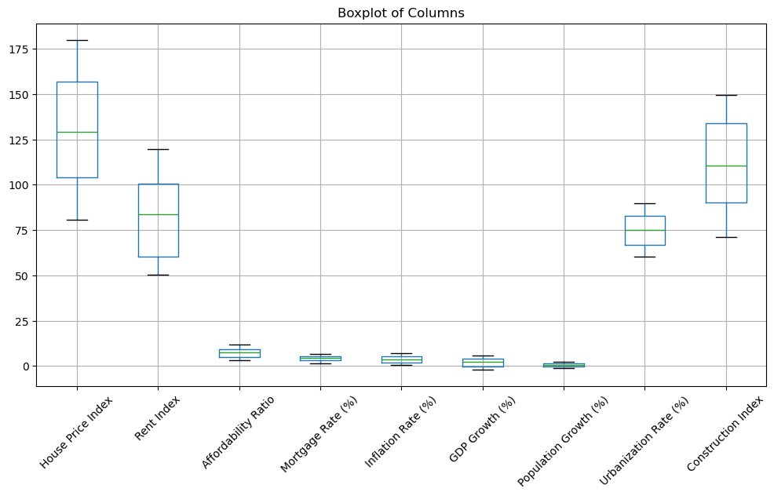

```python
#double checking for any outliers by creating a boxplot
df_new.boxplot(figsize=(12,6))
plt.title("Boxplot of Columns")
plt.xticks(rotation=45)
plt.show()
```

To check for any outliers a boxplot was created. This confirms that there are no outliers. This was done after turning "Year" into a category as to not skew the graph. Everything looks fine.

**Summary of Section**

There were no missing data or duplicates which meant the data needed very little editing. The only real editing done to the dataset was making the column "Year" a category so it can work well when creating a graph. A new csv file was created to save this change. In order to prove that there were no outliers after making "Year" a category a boxplot was created. It proved that there were no outliers in all of the data. Overall, this data came prepared essentially because there was barely any filtering needed for the dataset.

### Required Visualizations

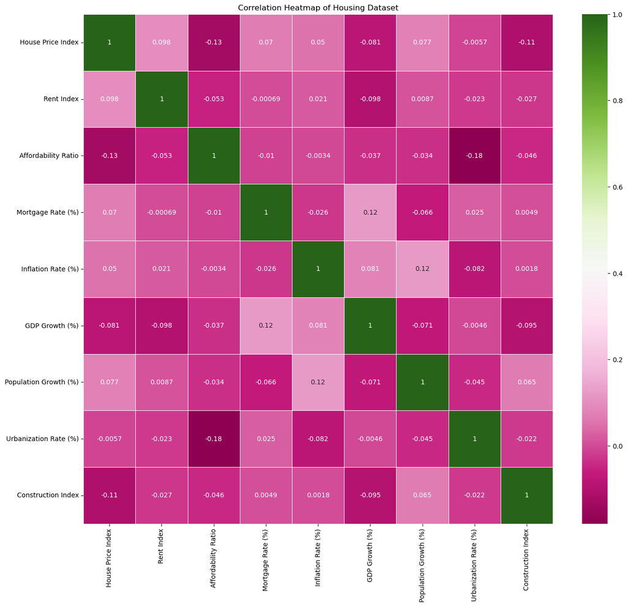

```python
#Establishing correlation
corr=df_new.corr(numeric_only=True)
#Creating a Heat Map
plt.figure(figsize=(16, 14))
sns.heatmap(corr, annot=True, cmap='PiYG', linewidths=0.5)
plt.title('Correlation Heatmap of Housing Dataset')
plt.savefig("Correlation_Heatmap_Housing.png")
plt.show()
```

The creation of this is to view correlations. There aren't really any strong correlations. The strongest for a positive correlation are GDP Growth % and Mortgage Rate % at 0.12, and Population Growth % and Inflation Rate % at 0.12, Rent Index and Price Index at 0.098. The strongest for negative correlation are House Price Index and Affordability Ratio at -0.13, Urbanization Rate and Affordability Ratio -0.18, and Construction Index and House Price Index -0.11.

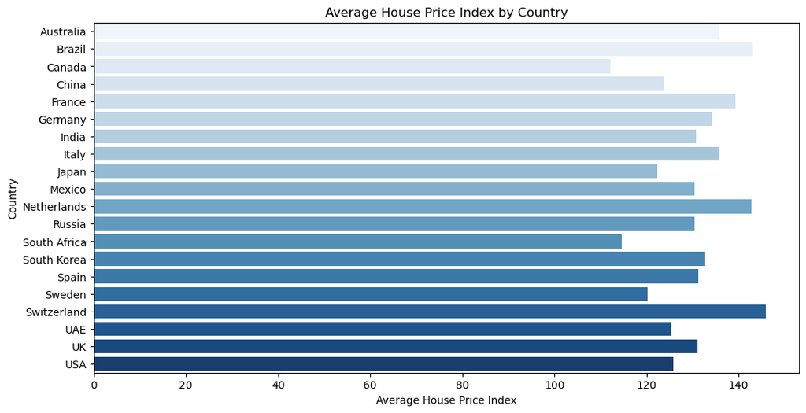

```python
#Creating a Bar Plot
plt.figure(figsize=(12,6))
sns.barplot(
    df_new.groupby("Country")["House Price Index"].mean().reset_index(),
    x="House Price Index",
    y="Country",
    palette="Blues"
)
#Labeling
plt.title("Average House Price Index by Country")
plt.xlabel("Average House Price Index")
plt.ylabel("Country")
plt.savefig('House_Price_Index_by_Country.png')
plt.show()
```

House Price Index tracks the changes in house prices over time. It shows changes in home values. The barplot shows the average House Price Index per country. Looking at the plot most countries Indexes are over 120, the two countries that fall below it are Canada and South Africa. A low House Price Index indicates homes are more inexpensive compared to the median income of that country. This implies that houses are more affordable in Canada and South Africa. Some of the highest House Price Indexes are above 140. Those countries are Brazil, Netherlands, and Switzerland. A high House Price Index indicates homes are more expensive compared to the median income of that country. Housing in these three countries are probably pretty pricey. Most of the countries fall in between 120 to 140 because of this it makes most of the countries look like they are closer to being on the expensive end when it comes to home prices.

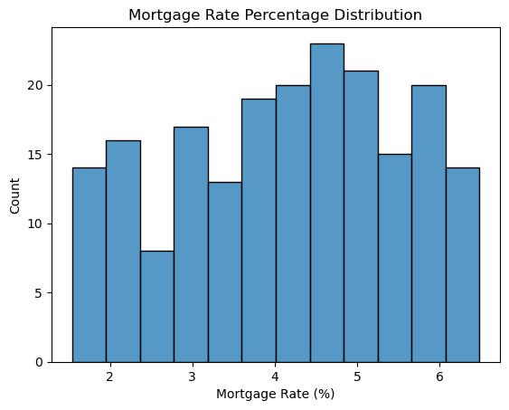

```python
#Creating A Mortgage rate histogram
Mortgage = df_new[['Mortgage Rate (%)']]
sns.histplot(Mortgage['Mortgage Rate (%)'], bins=12)
plt.title('Mortgage Rate Percentage Distribution')
plt.savefig("Histogram_Mortgage_Rate_Percentage.png")
plt.show()
```

This histogram looks at the frequency of Mortgage Rate % at different levels. A Mortgage Rate is the percentage of a loan someone pay to the loan lender in order to own their home. The Mortgage Rate percentage are lower numbers with decimals points. This can be seen in the graph due to multiple bars being in between whole numbers. The highest count of the Mortgage Rate % is in between 4 to 5. It raises the question of why so many countries have mortgages between 4 and 5. The lowest count is in between 2 and 3, it is the only one under the count of 10. Most of the different levels of Rates are above 10. There are four in between 10 to 15 and seven above 15. Based on the highest counts being between 4 to 5 it looks like a good portion of countries pay that Mortgage Rate Percentage.

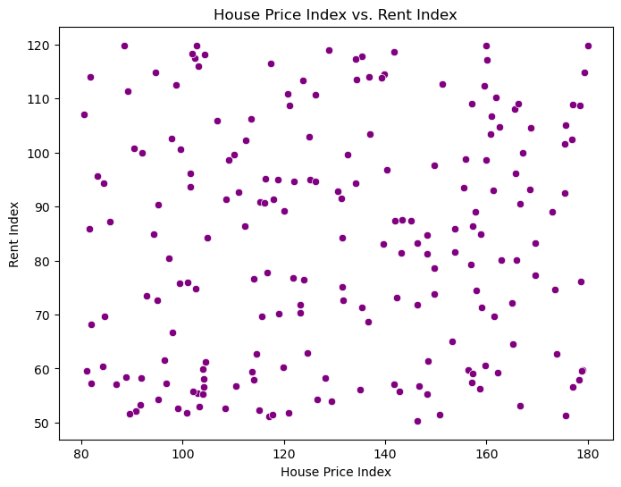

```python
#Creating a Scatterplot
plt.figure(figsize=(8,6))
sns.scatterplot(df_new,x="House Price Index",y="Rent Index",color="purple")
plt.title("House Price Index vs. Rent Index")
plt.xlabel("House Price Index")
plt.ylabel("Rent Index")
plt.savefig("scatterplot_hpi_vs_RentIndex.png")
plt.show()
```

The Rent Index is a measure that studies the change in rent prices over time. The House Price Index tracks the changes in house prices over time. Looking at the Scatter plot there does not seem to be a strong correlation between Rent Index and House Price Index. The data points on the plot look very spread out with no real pattern. Looking at the Heat map the Rent Index and House Price Index has a 0.098 correlation which is a weak correlation. Circling back to the Scatter Plot The Rent Index region with the most white would be in between 60 and 70. It did not really seem to matter what the House Price Index was the data points in this region seem fewer. There seems to be more of a population in between the 50 through 60 Rent Index especially near the 100 for the House Price Index. In general looking at this scatter plot feels like grasping at straws. There really does not seem to be much to work with for this chart.

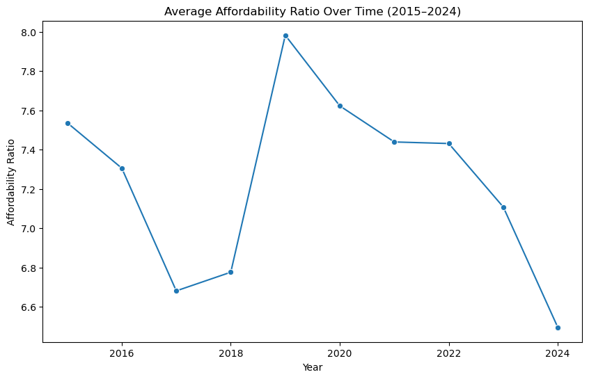

```python
#Creating a line plot
plt.figure(figsize=(10,6))
sns.lineplot(
    df_new.groupby("Year")["Affordability Ratio"].mean().reset_index(),
    x="Year",
    y="Affordability Ratio",
    marker="o"
)
plt.title("Average Affordability Ratio Over Time (2015–2024)")
plt.xlabel("Year")
plt.ylabel("Affordability Ratio")
plt.savefig("Lineplot_Affordability_Ratio.png")
plt.show()
```

The Affordability Ratio is a metric used to measure a household's ability to afford things relating to goods, services, and housing. A high Affordability Ratio means that housing is less affordable. Whereas a low affordability ratio means it is easier to afford things. It is notable that the lowest the Affordability Ratio was, was in 2024 being at 6.5 for Affordability Ratio. It makes one wonder what was lowering prices globally during 2024. The year 2019 was the most expensive just slightly below 8. But after 2019 there is a steady decline of the Affordability Ratio until 2024. The year 2024 was a drop compared to 2023. The global event that comes to mind that may have impacted affordabilty Ratio around 2019 and 2020 was the Covid-19 Pandemic. However, this dataset does not have columns for world events, so it is harder to connect the two events, but speculations can be made. Another aspect to consider is the incline from 2018 to 2019, it goes from just under 6.8 to just under 8. To summarize the line plot 2015 to 2017 declines from under 7.6 to around 6.7. Then there is an incline 2017 to 2019, from around 6.7 to slightly under 8. Then there's a drop from 2019 to 2024, from under 8 to 6.5. This entire line plot implies that the pendulum swings both ways. Houses may be affordable for a couple of years then get expensive for some time then go back to being cheaper.

```python
#Grouping House Price Index and Country
#Getting the average House Price Index for a Country
avg_hpi = df_new.groupby("Country")["House Price Index"].mean().reset_index()
#Creating a Geo Map
fig = px.choropleth(
    avg_hpi,
    locations="Country",
    locationmode="country names",
    color="House Price Index",
    color_continuous_scale="Blues",
    title="Geographic Distribution of Average House Price Index"
)
plt.savefig("GeoMap_HPI.png")
fig.show()
```

[interactive chart not shown]

Looking at the Geo Map the Highest House Price Index belongs to Brazil, the Netherlands, and Switzerland. A high House Price Index indicates homes are more expensive compared to the median income of that country. Brazil, the Netherlands, and Switzerland are very expensive in regards to housing. A low House Price Index indicates homes are more inexpensive compared to the median income of that country. Canada and South Africa are the cheapest by this measure. One of the issues with using a Geo Map is that it is harder to see the color of some of the smaller countries. Looking at this map in order to see Europe clearly it needed to be zoomed in. This dataset only has 20 countries so the countries that are colored on the map are very few. But this allows one to better visually compare Countries. The cluster of darker countries seem to be in Europe indicating higher prices for buying homes.

### Additional Visualizations

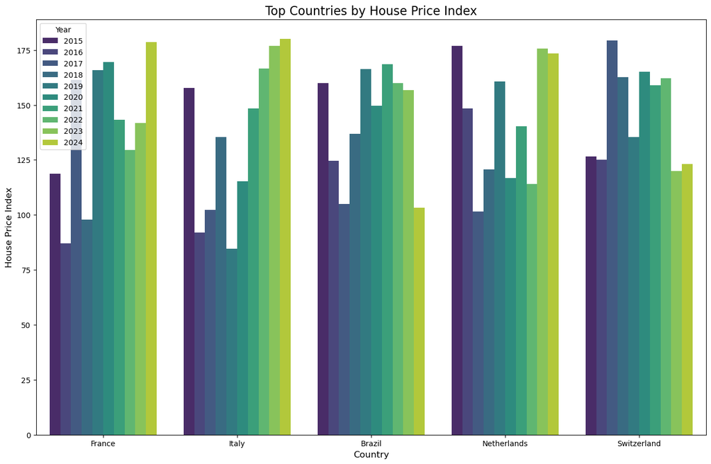

```python
# Calculate average House Price Index for each country
avg_by_country = df_new.groupby('Country')['House Price Index'].mean().reset_index()

# Sort and get top 5 countries
top_n = 5
top_countries = avg_by_country.sort_values('House Price Index', ascending=False).head(top_n)
top_country_list = top_countries['Country'].tolist()

# Filtering the dataframe to include only these top countries
filtered_df = df_new[df_new['Country'].isin(top_country_list)]

# Creating a bar plot showing affordability ratio by country and year
plt.figure(figsize=(16, 10))
sns.barplot(x='Country', y='House Price Index', hue='Year', data=filtered_df, palette='viridis')
plt.title('Top Countries by House Price Index', fontsize=16)
plt.xlabel('Country', fontsize=12)
plt.ylabel('House Price Index', fontsize=12)
plt.savefig("Top_Countries_by_HPI.png")
plt.show()
```

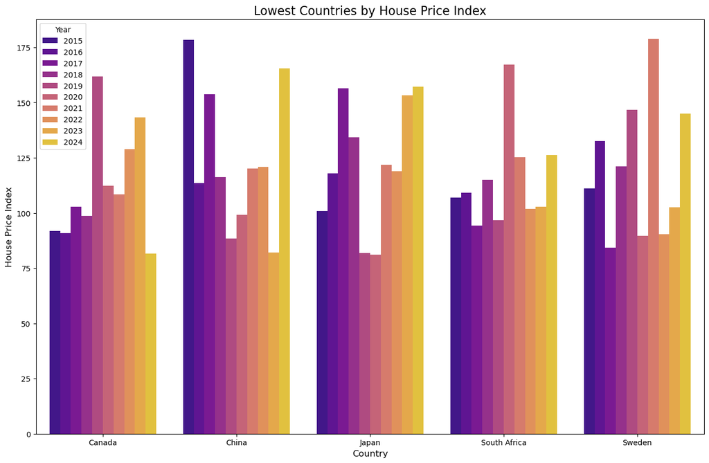

```python
# Calculate average House Price Index for each country
avg_by_country2 = df_new.groupby('Country')['House Price Index'].mean().reset_index()

# Sort and get bottom 5 countries
bottom_n = 5
low_countries = avg_by_country2.sort_values('House Price Index', ascending=False).tail(top_n)
low_country_list = low_countries['Country'].tolist()

# Filter the original dataframe to include only these bottom countries
df_filtered= df_new[df_new['Country'].isin(low_country_list)]

# Create a grouped bar plot showing House Price Index by country and year
plt.figure(figsize=(16, 10))
sns.barplot(x='Country', y='House Price Index', hue='Year', data=df_filtered, palette='plasma')
plt.title('Lowest Countries by House Price Index', fontsize=16)
plt.xlabel('Country', fontsize=12)
plt.ylabel('House Price Index', fontsize=12)
plt.savefig("Bottom_Countries_by_HPI.png")
plt.show()
```

For Bottom House Price Index the most part there is less frequent change with these countries as compared to the top House Price Index. It seems however that prices increased for most of these countries in 2024 except in Canada. That Japan and Sweden seemed to have a lower House Price Index around the 2020. This could potentially be explained by the Covid 19 pandemic. The lowest any of these countries reach is slightly above 75 and it is Japan.

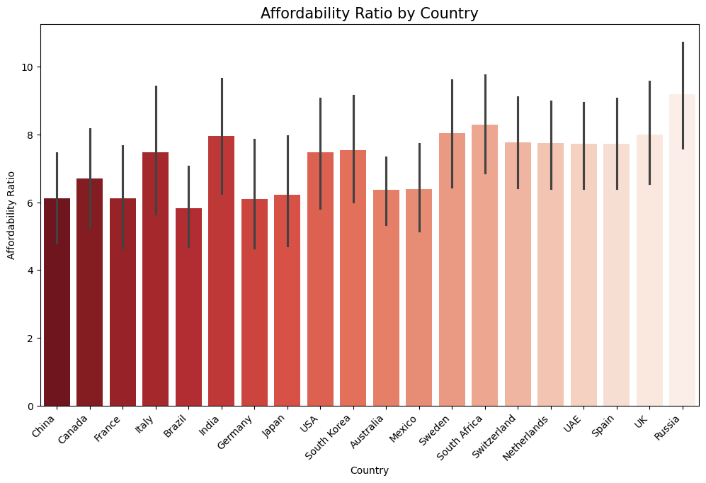

```python
# Sort countries from lowest to highest affordability
df_sorted = df_new.sort_values(by="Affordability Ratio", ascending=True)

#Creating the bar plot
plt.figure(figsize=(12, 7))
sns.barplot(
    data=df_sorted,
    x="Country",
    y="Affordability Ratio",
    hue="Country",
    palette="Reds_r",
    legend=False,
)
#Labeling
plt.title("Affordability Ratio by Country", fontsize=15)
plt.xlabel("Country")
plt.ylabel("Affordability Ratio")
plt.xticks(rotation=45, ha='right')
plt.savefig("Affordability_Ratio_Country.png")
plt.show()
```

The Affordability Ratio is a metric used to measure a household's ability to afford things relating to goods, services, and housing. A high Affordability Ratio means that housing is less affordable. Whereas a low affordability ratio means it is easier to afford things. It is interesting that Brazil is the lowest Affordability Ratio because on the Geo Map it indicated a high Price Index which means housing is more expensive. It implies that it is easy to purchase most things except a house. The highest Affordability Ratio is Russia which is interesting because that country did not seem to stand out in other charts. It makes one question why most things are harder to purchase. It looks like most countries Affordability Ratio is between 6 to 8.

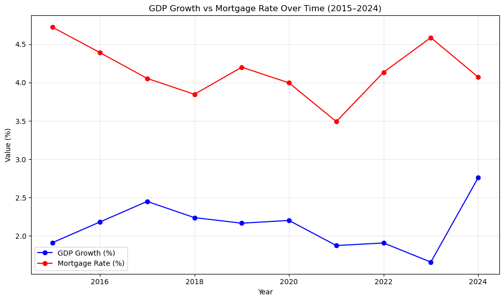

```python
#Grouping the year with GDP% and Mortgage Rate %
#It takes the average for each year
avg_year = df.groupby("Year")[["GDP Growth (%)", "Mortgage Rate (%)"]].mean().reset_index()
#Determining the size of figure
plt.figure(figsize=(10,6))
#Creating the GDP Line
plt.plot(avg_year["Year"], avg_year["GDP Growth (%)"],
         marker="o", label="GDP Growth (%)", color="blue")
#Creating the Mortgage Rate Line
plt.plot(avg_year["Year"], avg_year["Mortgage Rate (%)"],
         marker="o", label="Mortgage Rate (%)", color="red")
#Labeling
plt.title("GDP Growth vs Mortgage Rate Over Time (2015–2024)")
plt.xlabel("Year")
plt.ylabel("Value (%)")
plt.legend()
plt.grid(True, alpha=0.3)
plt.tight_layout()
plt.savefig('GDP_Growth_vs_Mortgage_Rate.png')
plt.show()
```

The GDP Growth % indicates a change in the value of goods and services produced. A high GDP Growth % shows that a country’s economy is doing well or experiencing a boost. A low GDP Growth % shows an economy is in decline. A Mortgage Rate is the percentage of a loan someone pay to the loan lender in order to own their home. The reason why this chart was created is that there is a correlation between GDP Growth % and Mortgage Rate % at 0.12. Looking at the line chart it is clear that the lines mirror each other to some extent, or is an inverse. When the GDP increases the Mortgage Rate decreases. When the GDP decreases it seems the Mortgage Rate increases. Some areas of the lines correlation are harder to see than others like in 2017 to 2018. That time frame seems to be when they both decrease. The lines do not intersect at any point. The Mortgage Rate is higher overall than the GDP Growth %. It seems that something good was happening in 2024 because the GDP Growth % goes up and the Mortgage Rate % goes down. That means in 2024, more countries experienced a growing economy, and their Mortgage Rates decreased. That seems like a great year.